# Homework 4

The code below will load replication from: [Hankinson, Michael. “When do renters behave like homeowners? High rent, price anxiety, and NIMBYism.” American political science review 112.3 (2018): 473-493.](https://dataverse.harvard.edu/dataset.xhtml?persistentId=doi:10.7910/DVN/CRPAA8&version=1.0)

The relevant variable descriptions can be downloaded from [this site](https://dataverse.harvard.edu/file.xhtml?persistentId=doi:10.7910/DVN/CRPAA8/RSFP0V&version=1.0#) and are under the heading “TESS National Survey”. (I’ve also included this table at the end of this document in case you can’t find it.)

```r
library(tidyverse)
library(marginaleffects)
library(ggeffects)
library(modelsummary)
library(labelled)
library(kableExtra)
```

```r
socpoc <- dataverse::get_dataframe_by_name(
  filename = "socpocAPSR.csv",
  .f=read_csv,
  dataset = "10.7910/DVN/CRPAA8&version=1.0",
  server = "dataverse.harvard.edu")|>
  select(-1)
socpoc<-socpoc|>
  mutate(own = factor(own, levels=c(0, 1),
                      labels=c("no", "yes")))

socpoc<-set_variable_labels(
  socpoc,
  'own' = 'homeowner',
  'supply_dummy' = 'support for increasing housing supply',
  'ideology' = 'liberal-conservative self-placement',
  'whitenh' = 'white non-hispanic',
  'income' = 'household income (group)'

)
```

# Question 1

Estimate the following bivariate model using a linear probability model and a logit or probit model.**

`supply_dummy ~ own`

What is the estimated effect of home-ownership on the probability that a respondent supports reduced restrictions on building new housing in this model? (state your answer in terms of the difference in % probability). Note any differences between your three models.

```r
# models

ols<- lm(supply_dummy ~
           own,
         data=socpoc)
logit<- glm(supply_dummy ~ own,
            data=socpoc,
            family='binomial')
probit<- glm(supply_dummy ~ own,
             data=socpoc,
             family='binomial'(link='probit'))

models_list<-list('ols' = ols,
                  'logit' = logit,
                  'probit' = probit
                  )

modelsummary(models_list,
             coef_rename=TRUE,
             #coef_omit = '(Intercept)',
             gof_omit = 'R2', # omit R2
             estimate  = "{estimate}",
             statistic = c("conf.int"),
             conf_level = .95,
             note = "95% CI in brackets",
             output='kableExtra'
             )
```

|  | ols | logit | probit |
| --- | --- | --- | --- |
| (Intercept) | 0.588 | 0.354 | 0.221 |
|  | [0.551, 0.625] | [0.192, 0.518] | [0.120, 0.323] |
| homeowner [yes] | −0.312 | −1.321 | −0.818 |
|  | [−0.357, −0.267] | [−1.525, −1.119] | [−0.942, −0.693] |
| Num.Obs. | 1909 | 1909 | 1909 |
| AIC | 2471.5 | 2358.3 | 2358.3 |
| BIC | 2488.2 | 2369.5 | 2369.5 |
| Log.Lik. | −1232.772 | −1177.172 | −1177.172 |
| F | 187.723 | 162.830 | 165.621 |
| RMSE | 0.46 | 0.46 | 0.46 |

95% CI in brackets

The OLS coefficient can be interpreted as the effect of home ownership relative to not being a homeowner: so homeowners are ~31 percentage points ($\pm 4.5$ points) less likely to support efforts to increase the housing supply in their area. This result is statistically significant at the 95% level.

Since there’s a single dummy variable here, the intercept term also has a meaningful interpretation: it represents the probability of supporting housing supply if the respondent rents their home. So, there’s 59% support for increasing housing supply among renters and $59 - 31 = 28\%$ support among homeowners.

The logit and probit coefficients don’t have this same intuitive interpretation, but we can get calculate this either by hand or by using a package like `marginaleffects`.

**Using the Inverse Link Function**

The probit and logit model will have different inverse link functions, but the steps here will otherwise be identical: we need to calculate a linear prediction for homeowners and renters the same way we would with a linear model, then we need to apply the inverse link function to get the predicted probabilities for each case. To calculate a marginal effect, we just need to find the difference between these two groups.

Rather than writing out the inverse link separately, we can actually access it from the model object itself by getting the `linkinv` element:

```r
# get the inverse logit
inverse_logit<-logit$family$linkinv

logit_coefs<-coef(logit)
# prediction for renters:
logit_renter_pred<-inverse_logit(logit_coefs["(Intercept)"])
# prediction for homeowners:
logit_owner_pred<-inverse_logit(
  logit_coefs["(Intercept)"] + logit_coefs["ownyes"] * 1)

# get the inverse probit
inverse_probit <- probit$family$linkinv

probit_coefs<-coef(probit)

# prediction for renters:
probit_renter_pred <-inverse_probit(probit_coefs["(Intercept)"])
# prediction for homeowners:
probit_owner_pred <- inverse_probit(
  probit_coefs["(Intercept)"] + probit_coefs["ownyes"] * 1)


tibble('link' = c("logit", "probit"),
       'homeowners' = c(logit_owner_pred, probit_owner_pred),
       'renters' = c(logit_renter_pred, logit_renter_pred),
       'marginal effect' = homeowners - renters
       )|>
  kbl(digits=3)|>
  kable_classic(full_width=FALSE)
```

| link | homeowners | renters | marginal effect |
| --- | --- | --- | --- |
| logit | 0.276 | 0.588 | -0.312 |
| probit | 0.276 | 0.588 | -0.312 |

**Using Predict**

Alternatively, we can use `predict` with the `newdata` argument to get the same result. We just need to create a new data frame containing the relevant values and we need to be sure to specify `type='response'`.

```r
new_data <- data.frame("own" = c("yes","no"))
logit_preds<-predict(logit, newdata=new_data, type='response')
probit_preds<-predict(probit, newdata=new_data, type='response')


mfx<-bind_rows(logit_preds, probit_preds)|>
  rename('owners' = `1`, 'renters' = `2` )|>
  mutate(model = c("logit", 'probit'),
         `marginal effect` = owners - renters
         )|>
  relocate(model)

mfx|>
  kbl(digits=3) |>
  kable_classic(full_width=FALSE)
```

| model | owners | renters | marginal effect |
| --- | --- | --- | --- |
| logit | 0.276 | 0.588 | -0.312 |
| probit | 0.276 | 0.588 | -0.312 |

**Using MarginalEffects**

We can use `avg_predictions` to get predicted probabilities for each group, and/or `avg_comparisons` to get marginal effects:

```r
avg_predictions(logit, variables='own')|>
  tibble()
```

| own | estimate | std.error | statistic | p.value | s.value | conf.low | conf.high |
| --- | --- | --- | --- | --- | --- | --- | --- |
| no | 0.5876461 | 0.02011313 | 29.21704 | 1.178142e-187 | 620.9640 | 0.5482251 | 0.6270671 |
| yes | 0.2755725 | 0.01234467 | 22.32320 | 2.199658e-110 | 364.2748 | 0.2513774 | 0.2997676 |

```r
avg_predictions(probit, variables='own')|>
  tibble()
```

| own | estimate | std.error | statistic | p.value | s.value | conf.low | conf.high |
| --- | --- | --- | --- | --- | --- | --- | --- |
| no | 0.5876461 | 0.02011312 | 29.21705 | 1.177960e-187 | 620.9643 | 0.5482251 | 0.6270671 |
| yes | 0.2755725 | 0.01234468 | 22.32319 | 2.200368e-110 | 364.2743 | 0.2513774 | 0.2997676 |

```r
avg_comparisons(probit)|>
  tibble()
```

| term | contrast | estimate | std.error | statistic | p.value | s.value | conf.low | conf.high | predicted_lo | predicted_hi | predicted |
| --- | --- | --- | --- | --- | --- | --- | --- | --- | --- | --- | --- |
| own | yes - no | -0.3120736 | 0.02359934 | -13.22382 | 6.392925e-40 | 130.2006 | -0.3583274 | -0.2658197 | 0.5876461 | 0.2755725 | 0.2755725 |

**Using GGeffects**

Finally, we can use the `predict_response` function from the `ggeffects` package to get predictions and use `test_predictions` to get a marginal effect across different levels of our predictions:

```r
predict_response(logit, terms='own')
```

| x | predicted | std.error | conf.low | conf.high | group |
| --- | --- | --- | --- | --- | --- |
| no | 0.5876461 | 0.08300296 | 0.5477441 | 0.6264286 | 1 |
| yes | 0.2755725 | 0.06183703 | 0.2520461 | 0.3004129 | 1 |

```r
predict_response(probit, terms='own')
```

| x | predicted | std.error | conf.low | conf.high | group |
| --- | --- | --- | --- | --- | --- |
| no | 0.5876461 | 0.05166812 | 0.5478481 | 0.6265621 | 1 |
| yes | 0.2755725 | 0.03695860 | 0.2519128 | 0.3002757 | 1 |

```r
# get a marginal effect
predict_response(logit, terms='own')|>
  test_predictions()
```

| own | Contrast | conf.low | conf.high | p.value |
| --- | --- | --- | --- | --- |
| no-yes | 0.3120736 | 0.2658197 | 0.3583274 | 6.392681e-40 |

# Question 2

Estimate a linear probability and logit/probit model with the same dependent variable, but include additional controls for ideology, white (non-hispanic) and income:

`supply_dummy ~ own + ideology + whitenh + income`

```r
form<-supply_dummy ~ own + ideology + whitenh + income # the model formula

ols2<-lm(form, data=socpoc)
logit2<-glm(form, data=socpoc, family='binomial'(link='logit'))
probit2<-glm(form, data=socpoc, family='binomial'(link='probit'))

models_list<-list('ols' = ols2,
                  'logit' = logit2,
                  'probit' = probit2
                  )

modelsummary(models_list,
             coef_rename=TRUE,
             #coef_omit = '(Intercept)',
             gof_omit = 'R2', # omit R2
             estimate  = "{estimate}",
             statistic = c("conf.int"),
             conf_level = .95,
             note = "95% CI in brackets",
             output='kableExtra'
             )
```

|  | ols | logit | probit |
| --- | --- | --- | --- |
| (Intercept) | 0.517 | 0.017 | 0.015 |
|  | [0.441, 0.594] | [−0.339, 0.374] | [−0.202, 0.231] |
| homeowner [yes] | −0.274 | −1.169 | −0.723 |
|  | [−0.323, −0.226] | [−1.393, −0.947] | [−0.860, −0.586] |
| liberal-conservative self-placement | 0.028 | 0.135 | 0.082 |
|  | [0.015, 0.041] | [0.071, 0.199] | [0.044, 0.120] |
| white non-hispanic | −0.085 | −0.392 | −0.238 |
|  | [−0.129, −0.040] | [−0.600, −0.183] | [−0.365, −0.111] |
| household income (group) | 0.000 | 0.000 | 0.000 |
|  | [0.000, 0.000] | [0.000, 0.000] | [0.000, 0.000] |
| Num.Obs. | 1878 | 1878 | 1878 |
| AIC | 2397.8 | 2287.3 | 2287.0 |
| BIC | 2431.0 | 2314.9 | 2314.7 |
| Log.Lik. | −1192.887 | −1138.627 | −1138.496 |
| RMSE | 0.46 | 0.46 | 0.46 |

95% CI in brackets

## 2A

What is the marginal effect of home ownership for a non-white “Extremely Conservative” respondent whose household income is less than $5,000 per year? Compare and contrast the estimates from the linear probability model and the logit/probit model.

**Predict**

To calculate this using “predict” we need to set up a data frame with all of the non-focal terms set at the values specified in the question, and the “own” variable set for renters and homeowners:

```r
new_data<-data.frame(
  "own" = c( "no", "yes"),
           "whitenh" = 0,
           "ideology" = 1,
           "income" = 3500)

# view the data
new_data
```

| own | whitenh | ideology | income |
| --- | --- | --- | --- |
| no | 0 | 1 | 3500 |
| yes | 0 | 1 | 3500 |

Then we need to generate predictions for each group. Here I’m using the `map` function to do this for all three models at once just to save a little copy-pasting:

```r
results<-models_list|>
  map( .f=~predict(.x, newdata=new_data, type='response'))|>
  bind_rows(.id ='model')|>
  rename(renter = `1`,
         homeowner = `2`
         )

results
```

| model | renter | homeowner |
| --- | --- | --- |
| ols | 0.5447053 | 0.2702569 |
| logit | 0.5369603 | 0.2648249 |
| probit | 0.5374834 | 0.2648038 |

Finally, we want to get the marginal effect of homeownership for each case, so we just take the prediction for homeowners minus the predictions for renters:

```r
results|>
  mutate(`marginal effect` = homeowner - renter)|>
  kbl(full_width=FALSE, digits=3)|>
  kable_classic()
```

| model | renter | homeowner | marginal effect |
| --- | --- | --- | --- |
| ols | 0.545 | 0.270 | -0.274 |
| logit | 0.537 | 0.265 | -0.272 |
| probit | 0.537 | 0.265 | -0.273 |

**MarginalEffects**

```r
new_data<-data.frame(
           "whitenh" = 0,
           "ideology" = 1,
           "income" = 3500)

mfx<-models_list|>
  map(.f=~avg_comparisons(.x, newdata=new_data, variables='own'))|>
  map(.f=tidy)|> # make a tibble
  bind_rows(.id='model')|> # combine results
  select(-rowid, -predicted, -p.value, -std.error) # remove some stats

mfx|>
  kbl(digits=3)|>
  kable_classic()
```

| model | term | contrast | estimate | statistic | s.value | conf.low | conf.high | predicted_lo | predicted_hi |
| --- | --- | --- | --- | --- | --- | --- | --- | --- | --- |
| ols | own | yes - no | -0.274 | -11.033 | 91.602 | -0.323 | -0.226 | 0.545 | 0.270 |
| logit | own | yes - no | -0.272 | -10.303 | 80.280 | -0.324 | -0.220 | 0.537 | 0.265 |
| probit | own | yes - no | -0.273 | -10.421 | 82.059 | -0.324 | -0.221 | 0.537 | 0.265 |

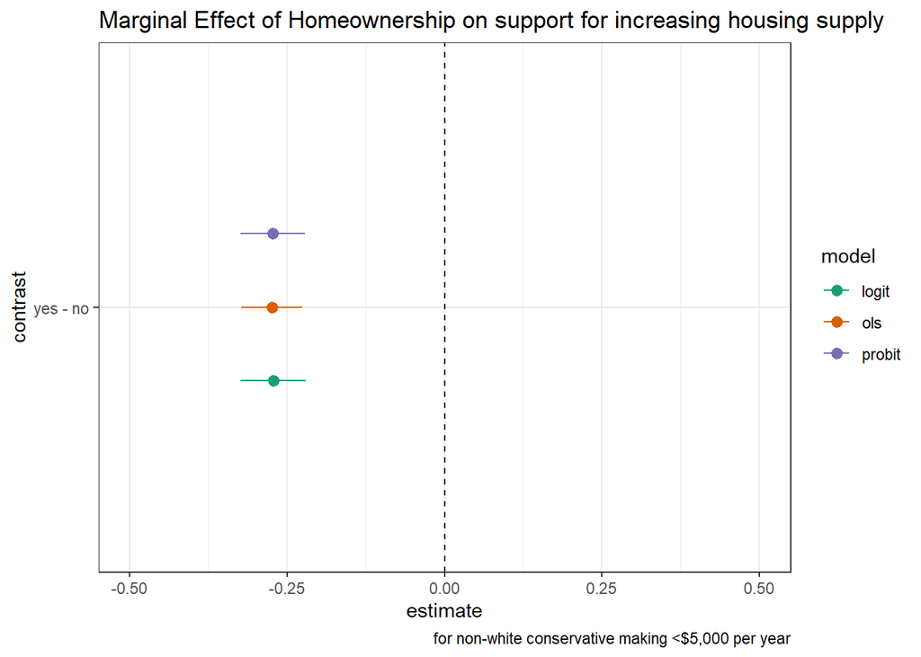

```r
mfx|>
  ggplot(aes(x=estimate,y=contrast,
             color=model, xmin=conf.low,
             xmax=conf.high))+
  geom_pointrange(position = position_dodge(width = 0.5)) +
  theme_bw() +
  xlim(c(-.5, .5)) +
  geom_vline(xintercept=0, lty=2) +
  scale_color_brewer(palette="Dark2") +
  labs(title = "Marginal Effect of Homeownership on support for increasing housing supply",
       caption="for non-white conservative making <$5,000 per year"
       )
```

**GGEffects**

We can get predictions from each object using `test_predictions`. The `condition` argument will have a named vector setting the values of the non-focal terms. The `terms` argument should be the variable you’re looking to get predictions from:

```r
effects<-test_predictions(logit2,
                 terms = 'own',
                 condition=c("whitenh" = 1,
                             "ideology" = 1,
                             "income" = 3500))
effects
```

| own | Contrast | conf.low | conf.high | p.value |
| --- | --- | --- | --- | --- |
| no-yes | 0.2435677 | 0.1911944 | 0.2959411 | 7.86527e-20 |

Or we can map over the list of models to do this for all three at once:

```r
out<-models_list|>
  map(.f=~test_predictions(.x,  terms='own',
                   condition=c("whitenh" = 1,
                               "ideology" = 1,
                             "income" = 3500))
      )|>
  bind_rows(.id='model')

out|>
  kbl(digits=3)|>
  kable_classic()
```

| model | own | Contrast | conf.low | conf.high | p.value |
| --- | --- | --- | --- | --- | --- |
| ols | no-yes | 0.274 | 0.226 | 0.323 | 0 |
| logit | no-yes | 0.244 | 0.191 | 0.296 | 0 |
| probit | no-yes | 0.250 | 0.198 | 0.301 | 0 |

## 2B

Finally, estimate the average effect of homeownership across all observations using the observed values/counterfactual approach. Note any differences in your results.

**Using Predict**

Start by creating two data sets: one where “own” is set to “no” for all respondents and another where “own” is set to “yes”, then get predictions for each new data set and calculate the mean difference:

```r
renters<-logit2$model|>
  mutate(own= 'no')|>
  predict(logit2, newdata=_, type='response')
owners<-logit2$model|>
  mutate(own= 'yes')|>
  predict(logit2, newdata=_, type='response')



mean(owners-renters)
```

```
[1] -0.271065
```

**Using MarginalEffects**

Marginal effects makes this very simple to calculate for every variable in the model. The empirical average difference is the default setting here:

```r
avg_comparisons(logit2)|>
  tidy()|>
  kbl(digits=3)|>
  kable_classic()
```

| term | contrast | estimate | std.error | statistic | p.value | s.value | conf.low | conf.high |
| --- | --- | --- | --- | --- | --- | --- | --- | --- |
| ideology | +1 | 0.028 | 0.007 | 4.144 | 0.00 | 14.840 | 0.015 | 0.042 |
| income | +1 | 0.000 | 0.000 | -1.058 | 0.29 | 1.785 | 0.000 | 0.000 |
| own | yes - no | -0.271 | 0.026 | -10.234 | 0.00 | 79.249 | -0.323 | -0.219 |
| whitenh | 1 - 0 | -0.084 | 0.023 | -3.631 | 0.00 | 11.789 | -0.129 | -0.039 |

Doing it for all three models and then generating a plot:

```r
mfx<-models_list|>
  map(.f=avg_comparisons)|>
  map(tidy)|>
  bind_rows(.id='model')

mfx|>
  filter(term=='own')
```

| model | term | contrast | estimate | std.error | statistic | p.value | s.value | conf.low | conf.high |
| --- | --- | --- | --- | --- | --- | --- | --- | --- | --- |
| ols | own | yes - no | -0.2744484 | 0.02487620 | -11.03257 | 2.661456e-28 | 91.60177 | -0.3232049 | -0.2256920 |
| logit | own | yes - no | -0.2710650 | 0.02648596 | -10.23429 | 1.392096e-24 | 79.24902 | -0.3229765 | -0.2191535 |
| probit | own | yes - no | -0.2717926 | 0.02640555 | -10.29301 | 7.577091e-25 | 80.12656 | -0.3235465 | -0.2200387 |

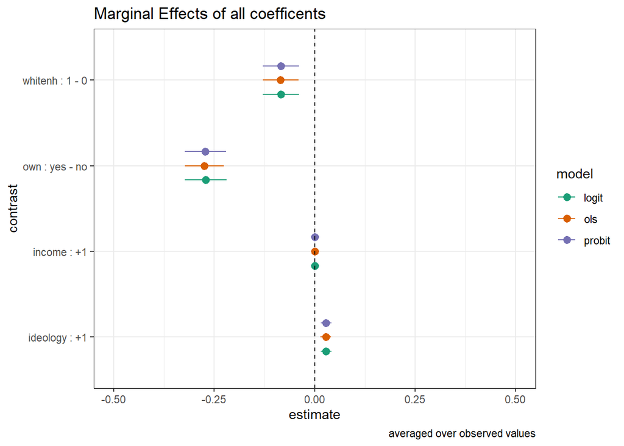

```r
mfx|>
  mutate(contrast = paste(term,":", contrast))|>
ggplot(aes(x=estimate,y=contrast,
             color=model, xmin=conf.low,
             xmax=conf.high))+
  geom_pointrange(position = position_dodge(width = 0.5)) +
  theme_bw() +
  xlim(c(-.5, .5)) +
  geom_vline(xintercept=0, lty=2) +
  scale_color_brewer(palette="Dark2") +
    labs(title = "Marginal Effects of all coefficents",
       caption="averaged over observed values"
       )
```

The primary thing to note here is that the logit/probit marginal effects are very slightly different from the ones we estimated in Question 2A because of how we’ve handled the non-focal predictors. Nevertheless, all three models are within a few digits of each other.

This difference doesn’t appear in the results for the OLS model, because this model is linear.

# Variable Descriptions

| Variable | Description |
| --- | --- |
| own | “1” = Homeowner, “0” = Renter. |
| city_supply | “From your ZIP code, you live in [INSERT CITY NAME], which has [INSERT TOTAL NUMBER OF UNITS BY CITY] housing units (homes and apartments). Imagine [INSERT CITY NAME] lowers development restrictions, … |
| supply_dummy | Dichotomize city_supply (“1” = “Somewhat Support”, “Support”, and “Strongly Support”; “0” = “Somewhat Oppose”, “Oppose”, “Strongly Oppose”; NA = “Neutral/Uncertain”.) |
| ideology | “In general, do you think of yourself as… (”Extremely liberal”=“7”, “Liberal”=“6”, “Slightly liberal”=“5”, “Moderate, middle of the road”=“4”, “Slightly conservative”=“3”, “Conservative”=“2”, “Extreme… |
| income | Household income (“Less than $5,000”=“1”, “$5,000 to $7,499”=“2”, “$7,500 to $9,999”=“3”, “$10,000 to $12,499”=“4”,“$12,500 to $14,999”=“5”, “$15,000 to $19,999”=“6”, “$20,000 to $24,999”=“7”, “$25,00… |
| whitenh | Dummy variable (“1” = White, Non-Hispanic, “0” = All other possibilities) |
| age | Transformed from ranges to average value of range (“18-24”=“21”,“25-34”=“29”,“35-44”=“39”,“45-54”=“49”, “55-64”=“59”,“65-74”=“69”,“75+”=“79”)) |
| male | “1” = Male, “0” = Female. |
| name | Name of municipality. |
| zri_city | Citywide average rent, Zillow.com, June 2016. |
| zri | ZIP code average rent, Zillow.com, June 2016. |
| neighborhood_ban | “Would you support a ban on the construction of new housing (homes and apartments) in your neighborhood?” (1 = “Strongly Oppose”, 2 = “Oppose”, 3 = “Somewhat Oppose”, 4 = “Neutral/Uncertain”, 5 = “Som… |
| ban_dummy | Dichotomize neighborhood_ban (1 = “Somewhat Support”, “Support”, and “Strongly Support”; 0 = “Somewhat Oppose”, “Oppose”, “Strongly Oppose”; NA = “Neutral/Uncertain”.) |